# Tutorial 01 — Your First Simulation

This tutorial introduces the complete **pbisim workflow** from scratch. No prior knowledge of pharmacokinetics or mathematical modelling is assumed.

**What you will learn**

1. What pbisim models conceptually
2. The four-step pipeline: **build → assemble → integrate → read**
3. How to inspect and visualise a `SimulationResult`
4. How initial conditions and phage dose affect the outcome

## 1 What does pbisim model?

pbisim simulates the coupled dynamics of bacteria and bacteriophage (phage) inside a patient, represented as a system of ordinary differential equations (ODEs).

The core state variables tracked over time are:

| Symbol | Meaning | Typical units |
| --- | --- | --- |
| **B** | Proliferating (active) bacteria | cells / mL |
| **P** | Free phage at the infection site | PFU / mL |
| **I** | Infected-but-not-yet-lysed bacteria | cells / mL |
| **S** | Nutrient substrate | (relative) |
| **Imm** | Immune effector concentration | (relative) |

Optional extensions (dormancy, pharmacokinetics, antibiotics) add further compartments. Every tutorial introduces exactly one new layer.

> **Design principle:** you never need to construct the internal parameter object (`ModelConfig`) by hand. The builder APIs — `ModelBuilder`, `StrainSet`, `BinaryResistanceGenotypes` — do this for you.

## 2 Imports

```python
import numpy as np
import matplotlib.pyplot as plt

from pbisim import ModelBuilder, PBIModel, solve_ode
from pbisim.analysis.single import plot_simulation
```

## 3 Step 1 — Build a `ModelConfig` with `ModelBuilder`

`ModelBuilder` uses a fluent (chained) API. Every `with_*()` call returns a new builder; `build()` produces the immutable parameter object.

The example below models **one bacterial strain** growing on a nutrient substrate, challenged by **one phage species**. All parameters have biologically sensible defaults — you only write what differs from them.

```python
cfg = (
    ModelBuilder(n_bacteria=1, n_phages=1, n_latent=5)
    # Bacterial growth and resource consumption
    .with_growth_rates(1.2,                            # maximum growth rate (h⁻¹)
                       bacteria_to_resource_ratio=1e9) # cells per nutrient unit
    # Phage–bacteria interaction parameters
    .with_phage_params(
        adsorption_rates    = 2e-9,   # mL h⁻¹ — typical in-vivo phage–bacteria binding
        burst_sizes         = 50.0,   # phage released per lysed cell
        latent_periods      = 0.5,    # h from infection to lysis
        phage_decay_rates   = 0.1,    # h⁻¹  free-phage clearance at infection site
    )
    # Nutrient dynamics
    .with_nutrient(monod_constant=0.3,   # half-saturation for Monod growth
                   recycle_fraction=0.0) # fraction of dead-cell biomass returned to S
    .build()
)

print("n_bacteria:", cfg.n_bacteria)
print("n_phages:  ", cfg.n_phages)
print("n_latent:  ", cfg.n_latent,   "  (latent-stage compartments per strain–phage pair)")
```

```
n_bacteria: 1
n_phages:   1
n_latent:   5   (latent-stage compartments per strain–phage pair)
```

## 4 Step 2 — Assemble a `PBIModel` with initial conditions

`PBIModel` binds the parameters (`cfg`) to starting values and implements the ODE right-hand side. Units must be consistent throughout: cells / mL for bacteria, PFU / mL for phage, and the same nutrient units as `monod_constant`.

```python
model = PBIModel(
    cfg,
    initial_B   = np.array([1e7]),   # 10⁷ bacteria / mL  (MOI ≈ 0.1)
    initial_P   = np.array([1e6]),   # 10⁶ phage / mL
    initial_S   = 1.0,               # normalised nutrient (1 = replete)
)
```

## 5 Step 3 — Integrate with `solve_ode`

`solve_ode` wraps `scipy.integrate.solve_ivp`. You specify the time horizon (`t_end`, hours) and the output resolution (`dt`, hours).

```python
result = solve_ode(model, t_end=48.0, dt=0.25)

print("Time points:", len(result.time))
print("State variables:", result.state_names[:6], "...")
```

```
Time points: 193
State variables: ['B0', 'P0', 'I0_0_0', 'I1_0_0', 'I2_0_0', 'I3_0_0'] ...
```

## 6 Step 4 — Read a `SimulationResult`

`result.get(key)` returns the time series for a named state variable. For multi-strain or multi-phage models, use `result.sum_prefixes(...)` to aggregate across compartments.

| Method | Returns |
| --- | --- |
| `result.get("B0")` | Time series for bacterium strain 0 |
| `result.get("P0")` | Time series for phage species 0 |
| `result.get("S")` | Nutrient substrate |
| `result.get("Imm")` | Immune effector |
| `result.sum_prefixes("B","I","D","H")` | Total bacteria (all compartments) |
| `result.sum_prefixes("P")` | Total free phage |

```python
t    = result.time
B    = result.get("B0")    # active bacteria, strain 0
P    = result.get("P0")    # free phage, species 0
S    = result.get("S")     # nutrient
Imm  = result.get("Imm")  # immune effector (zero here — not yet configured)

print(f"Peak bacteria: {B.max():.2e} cells/mL at t = {t[B.argmax()]:.1f} h")
print(f"Min  bacteria: {B.min():.2e} cells/mL")
print(f"Final phage:   {P[-1]:.2e} PFU/mL")
```

```
Peak bacteria: 1.67e+08 cells/mL at t = 3.5 h
Min  bacteria: -6.06e-24 cells/mL
Final phage:   1.68e+08 PFU/mL
```

## 7 Visualise with `plot_simulation`

`plot_simulation` produces a four-panel overview automatically. It returns `(fig, axes)` so you can further customise.

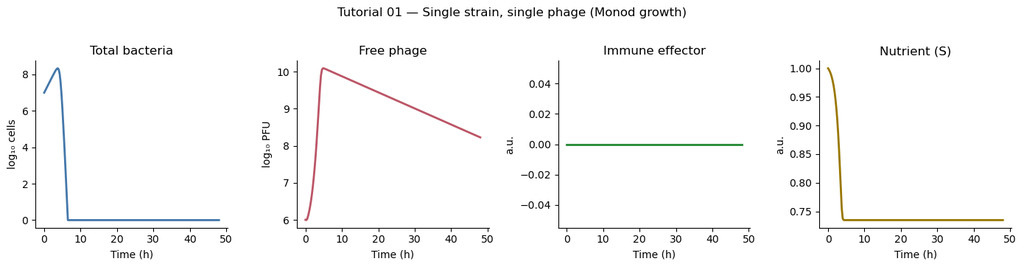

```python
fig, axes = plot_simulation(result)
fig.suptitle("Tutorial 01 — Single strain, single phage (Monod growth)", y=1.02)
plt.tight_layout()
plt.show()
```

## 8 Interpreting the dynamics

Let's draw this on a single panel to highlight the timescales:

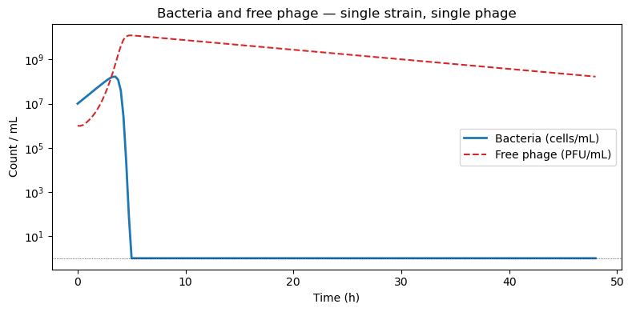

```python
fig, ax = plt.subplots(figsize=(8, 4))
ax.semilogy(t, np.maximum(B, 1),   "C0-",  lw=2,  label="Bacteria (cells/mL)")
ax.semilogy(t, np.maximum(P, 1),   "C3--", lw=1.5, label="Free phage (PFU/mL)")
ax.axhline(1, color="k", lw=0.5, ls=":")
ax.set(xlabel="Time (h)", ylabel="Count / mL",
       title="Bacteria and free phage — single strain, single phage")
ax.legend()
plt.tight_layout()
plt.show()
```

## 9 Exploring the effect of initial phage dose

A key clinical question is: **how much phage must be administered to achieve rapid bacterial clearance?** Bacterial nadir (the lowest count reached) is a poor discriminator when all doses eventually drive bacteria to near-zero — instead, **time to 99% decline** (the first time B drops below 1% of the starting count) is a more informative pharmacodynamic endpoint.

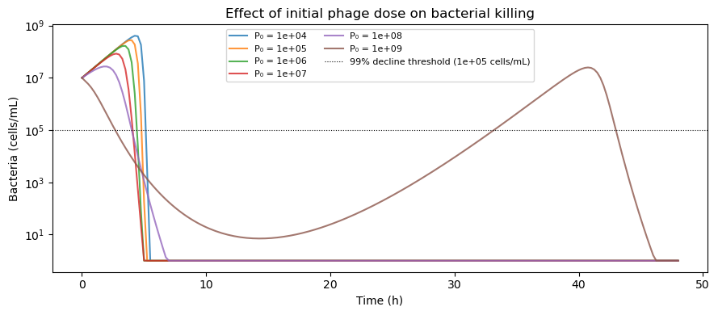

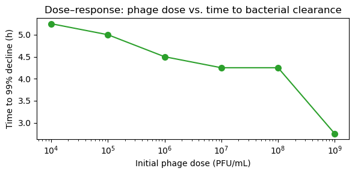

```
Doses that never achieved 99% decline within 48 h: none
```

```python
B0_init   = 1e7
threshold = B0_init * 0.01   # 99% decline endpoint = 1e5 cells/mL
doses     = np.logspace(4, 9, 6)   # 10⁴ … 10⁹ PFU/mL
t_decline = []

fig, ax = plt.subplots(figsize=(9, 4))

for P0 in doses:
    m   = PBIModel(cfg, initial_B=np.array([B0_init]),
                   initial_P=np.array([P0]), initial_S=1.0)
    res = solve_ode(m, t_end=48.0, dt=0.25)
    B_t = res.get("B0")
    ax.semilogy(res.time, np.maximum(B_t, 1), alpha=0.8,
                label=f"P₀ = {P0:.0e}")
    # First time point where B crosses below the threshold
    below = np.where(B_t < threshold)[0]
    t_decline.append(float(res.time[below[0]]) if len(below) > 0 else np.nan)

ax.axhline(threshold, ls=":", color="k", lw=0.8,
           label=f"99% decline threshold ({threshold:.0e} cells/mL)")
ax.set(xlabel="Time (h)", ylabel="Bacteria (cells/mL)",
       title="Effect of initial phage dose on bacterial killing")
ax.legend(fontsize=8, ncol=2)
plt.tight_layout()
plt.show()

# Time-to-99%-decline vs dose
valid = [(d, t) for d, t in zip(doses, t_decline) if not np.isnan(t)]
fig2, ax2 = plt.subplots(figsize=(6, 3))
if valid:
    d_vals, t_vals = zip(*valid)
    ax2.semilogx(d_vals, t_vals, "o-C2", markersize=7)
# Mark doses that never achieved the threshold
no_decline = [d for d, t in zip(doses, t_decline) if np.isnan(t)]
for d in no_decline:
    ax2.axvline(d, color="C3", ls=":", lw=1)
ax2.set(xlabel="Initial phage dose (PFU/mL)",
        ylabel="Time to 99% decline (h)",
        title="Dose–response: phage dose vs. time to bacterial clearance")
plt.tight_layout()
plt.show()
print("Doses that never achieved 99% decline within 48 h:",
      [f"{d:.0e}" for d in no_decline] or "none")
```

## 10 Summary

| Step | Object | Purpose |
| --- | --- | --- |
| **Build** | `ModelBuilder(...).with_*().build()` | Define parameters |
| **Assemble** | `PBIModel(cfg, initial_B=..., initial_P=...)` | Set initial conditions |
| **Integrate** | `solve_ode(model, t_end=..., dt=...)` | Run the ODE |
| **Read** | `result.get("B0")`, `result.sum_prefixes(...)` | Extract time series |

**Next tutorial:** *Growth functions and nutrient dynamics* — how to switch between Monod, logistic, constant, and other growth models, and when to freeze the nutrient state with `track_nutrients=False`.